# Lab 4a

Vista Sohrab

9/14/2020

## Data Visualization with ggplot2

```r
library(tidyverse)
library(hexbin)
library(gridExtra)
```

## Plotting with ggplot2

Importing the surveys_complete.csv file:

```r
surveys_complete <- read_csv("data/surveys_complete.csv")
```

Scatterplot of weight vs hindfoot length using the survey_complete dataframe:

```r
ggplot(data=surveys_complete, mapping=aes(x=weight, y=hindfoot_length)) + geom_point()+ theme_bw()
```

Alternative method of adding layers to a ggplot by assigning plot to a variable:

```r
surveys_plot <- ggplot(data=surveys_complete, mapping=aes(x=weight, y=hindfoot_length))
surveys_plot + geom_point() + theme_bw()
```

## Optional Challenge

The hexagonal plot has a heat map associated with the number of points belonging to a particular hexagonal bin which helps with reducing overplotting in large datasets. The hexagonal plot seems to show the general trend without overwhelming the viewer while providing the number of points belonging to a particular bin. The scatterplot however provides more detail since all individual points that are not overplotted can be mainly seen while the hexagonal plot combines several points into one bin and the range of points within that bin remains unknown to the viewer as a single dark blue bin could encompass a single point to 500 points.

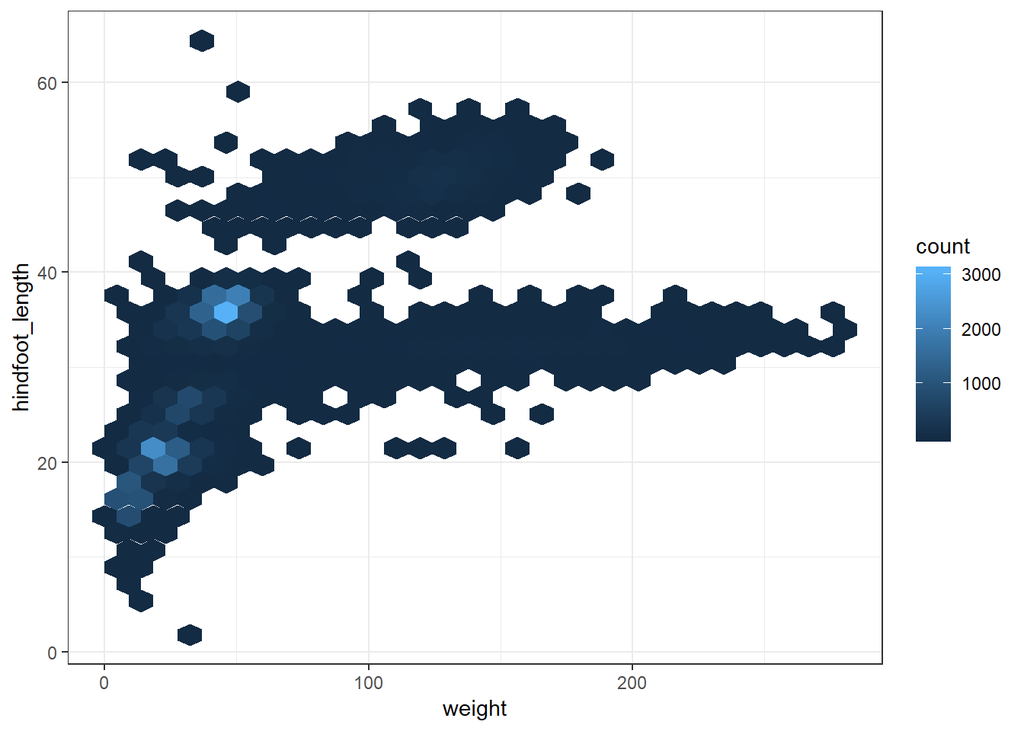

```r
surveys_plot +
 geom_hex() + theme_bw()
```

## Building Plots Iteratively

```r
ggplot(data = surveys_complete, aes(x = weight, y = hindfoot_length)) +
    geom_point() + theme_bw()
```

Adding transparency using alpha parameter to avoid overplotting:

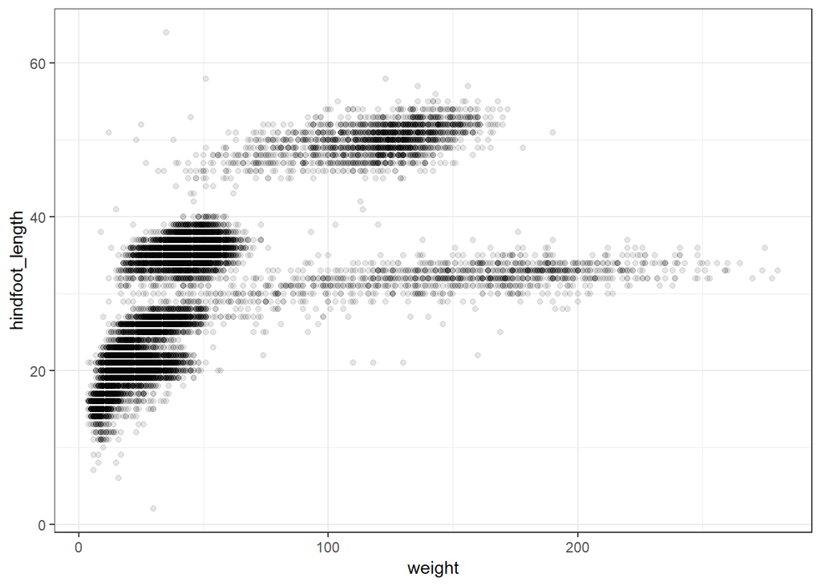

```r
ggplot(data = surveys_complete, aes(x = weight, y = hindfoot_length)) +
    geom_point(alpha = 0.1) + theme_bw()
```

Adding color to the scatterplot:

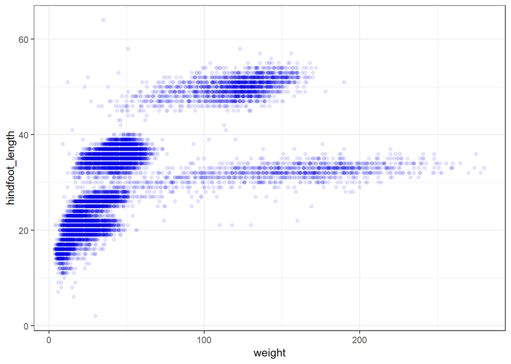

```r
ggplot(data = surveys_complete, mapping = aes(x = weight, y = hindfoot_length)) +
    geom_point(alpha = 0.1, color = "blue") + theme_bw()
```

Each species can be colored differently in the plot by using a vector as input to the color argument.

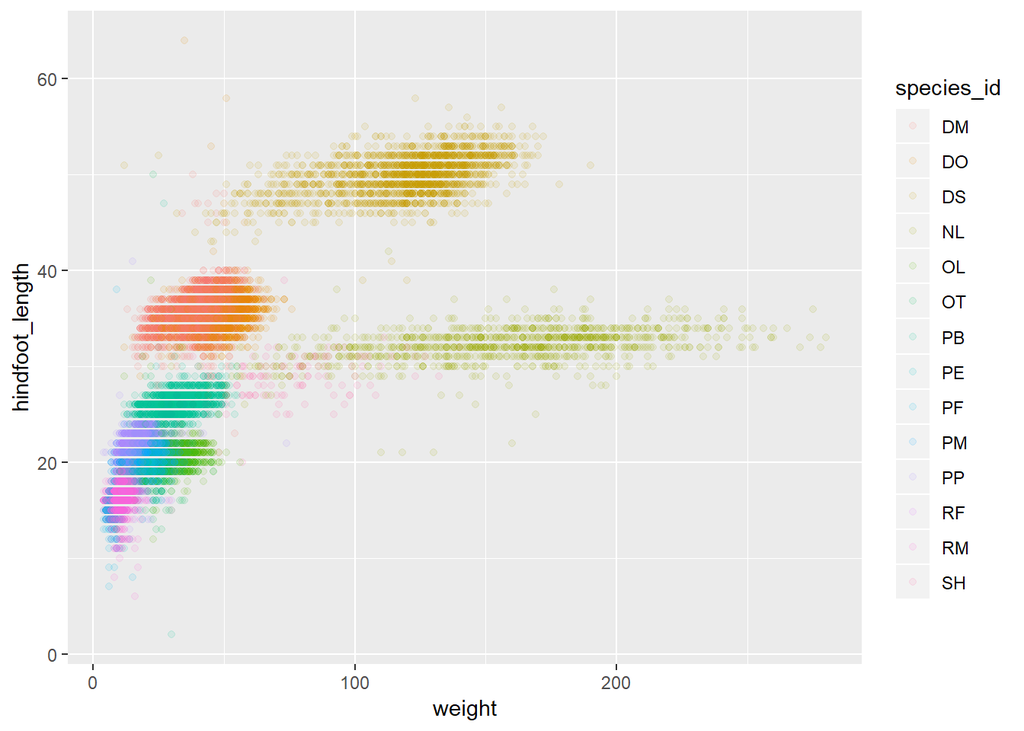

```r
ggplot(data = surveys_complete, mapping = aes(x = weight, y = hindfoot_length)) +
    geom_point(alpha = 0.1, aes(color = species_id))
```

## Challenge 1

The plot is slightly difficult to interpet.

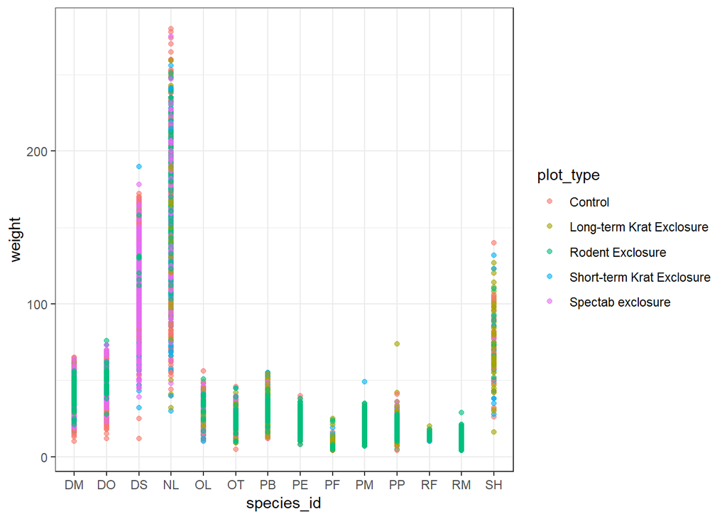

```r
ggplot(data = surveys_complete, mapping = aes(x = species_id, y = weight)) +
  geom_point(alpha = 0.6, aes(color = plot_type)) + theme_bw()
```

## Boxplot

Visualizing the distribution of weight for each species:

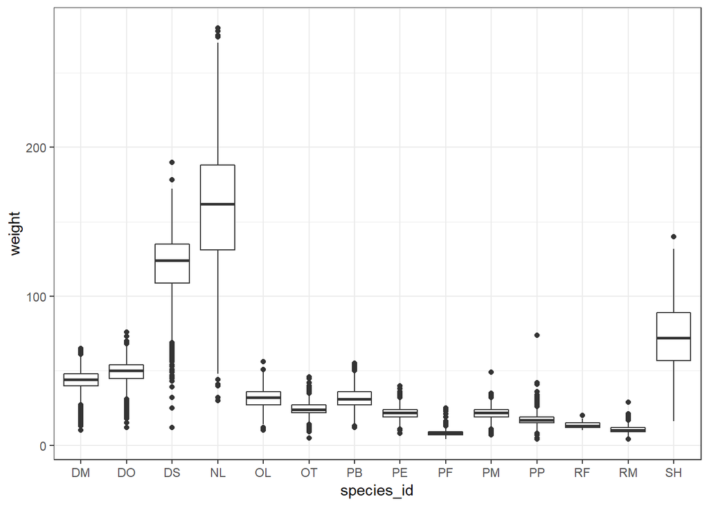

```r
ggplot(data = surveys_complete, mapping = aes(x = species_id, y = weight)) +
    geom_boxplot() + theme_bw()
```

Adding points to boxplots to give a better indication of the number of measurements and their distribution:

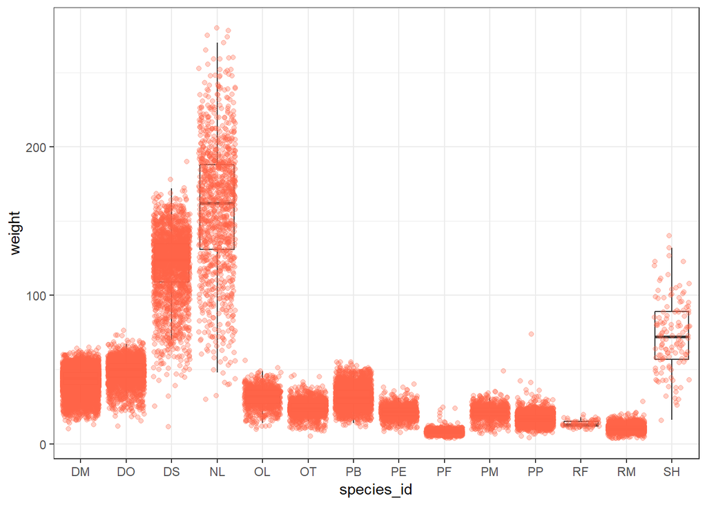

```r
ggplot(data = surveys_complete, mapping = aes(x = species_id, y = weight)) +
    geom_boxplot(alpha = 0) +
    geom_jitter(alpha = 0.3, color = "tomato") +
    theme_bw()
```

Boxplot in front of the points:

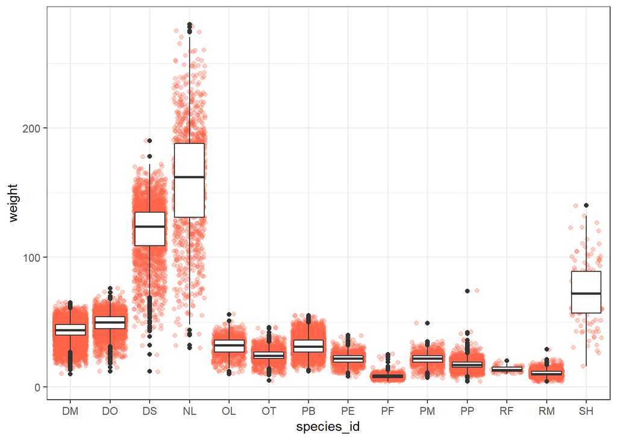

```r
ggplot(data = surveys_complete, mapping = aes(x = species_id, y = weight)) +
    geom_jitter(alpha = 0.3, color = "tomato") +
    geom_boxplot() +
    theme_bw()
```

## Challenge 2

- Replacing boxplot with a violin plot:

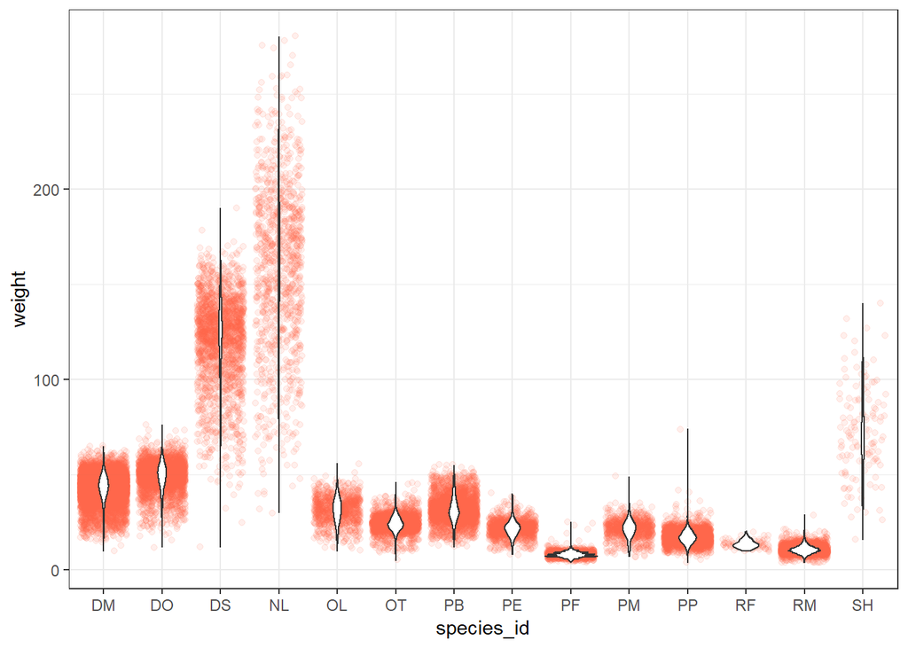

```r
ggplot(data = surveys_complete, mapping = aes(x = species_id, y = weight)) +
    geom_jitter(alpha = 0.1, color = "tomato") +
    geom_violin() + theme_bw()
```

- Represent weight on the log 10 scale

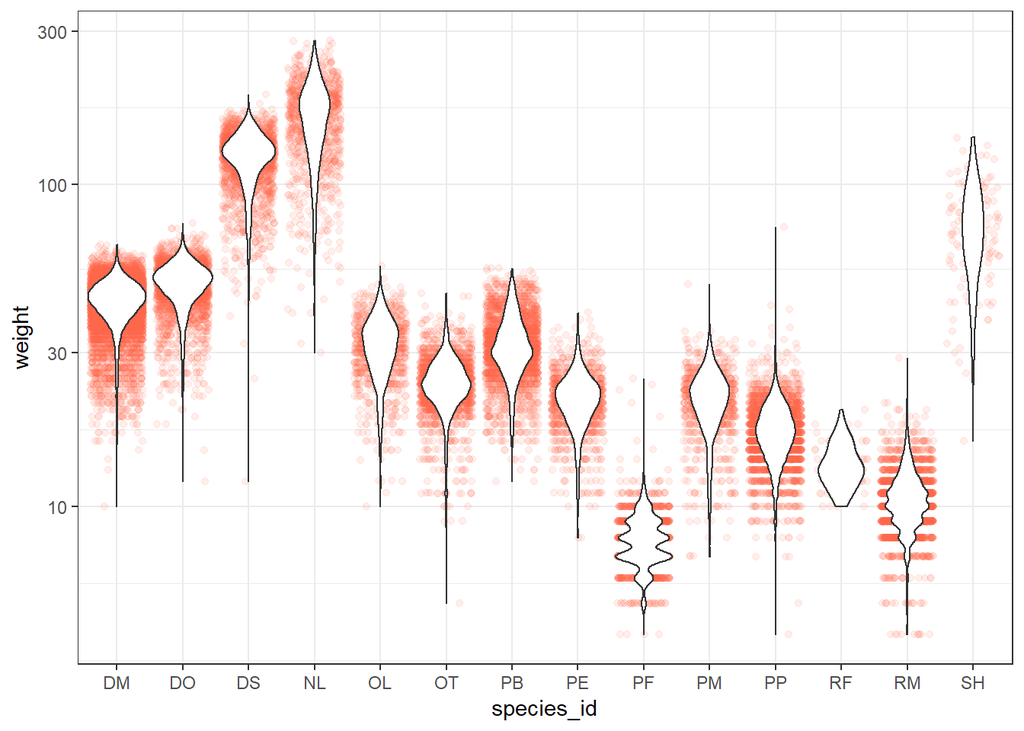

```r
ggplot(data = surveys_complete, mapping = aes(x = species_id, y = weight)) +
    geom_jitter(alpha = 0.1, color = "tomato") +
    geom_violin() + scale_y_log10() + theme_bw()
```

- Boxplot for hindfoot_length:

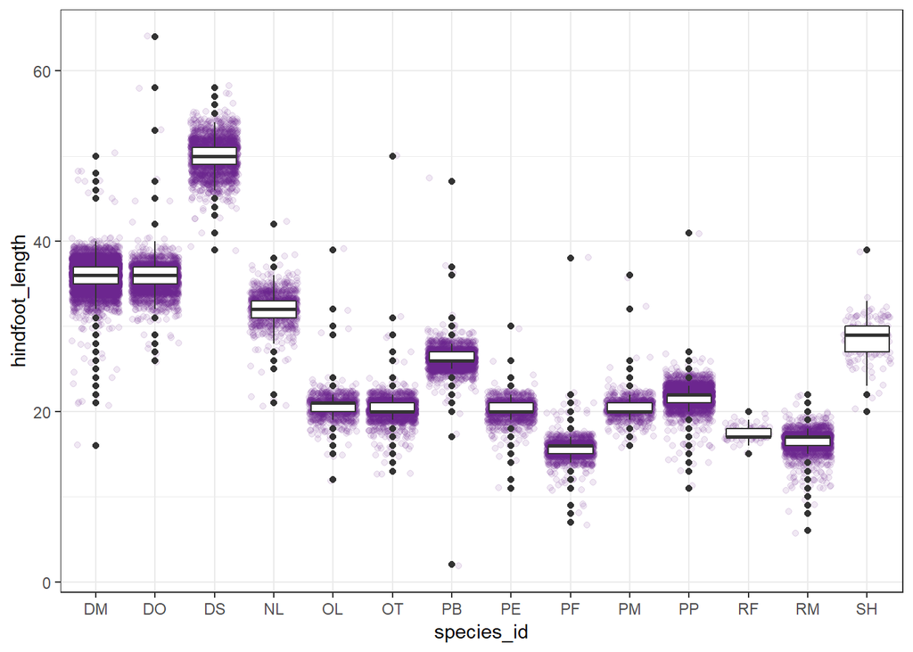

```r
ggplot(data= surveys_complete, mapping = aes(x = species_id, y = hindfoot_length)) +
  geom_jitter(alpha = 0.1, color = "dark orchid4") +
  geom_boxplot() + theme_bw()
```

- Adding color to boxplots according to plot_id:

```r
typeof(surveys_complete$plot_id)
```

```
## [1] "double"
```

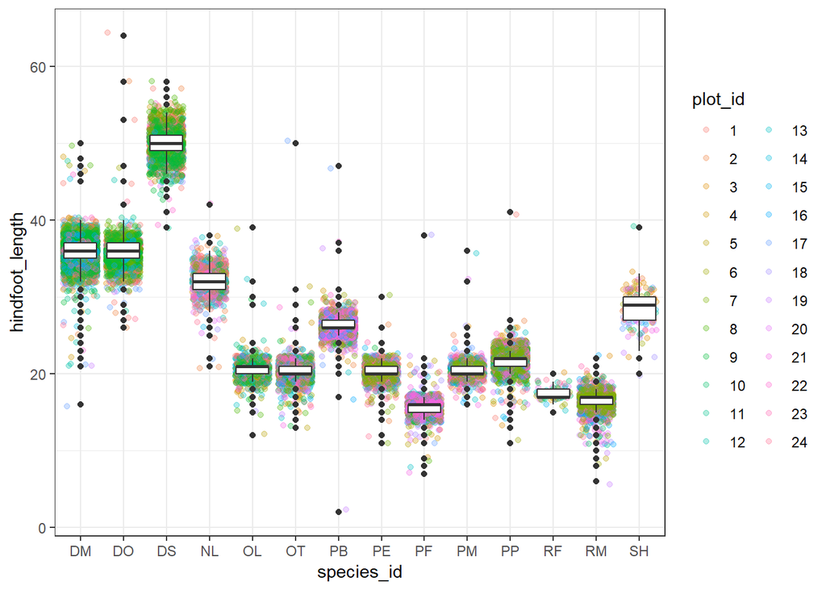

```r
surveys_complete$plot_id <- factor(surveys_complete$plot_id)

ggplot(data= surveys_complete, mapping = aes(x = species_id, y = hindfoot_length)) +
  geom_jitter(alpha = 0.3, aes(color = plot_id)) +
  geom_boxplot() + theme_bw()
```

## Plotting Time Series Data

To calculate the number of counts each year for each genus, the data needs to be grouped and records counted within that group.

```r
yearly_counts <- surveys_complete %>%
  count(year, genus)

yearly_counts
```

```
## # A tibble: 191 x 3
##     year genus               n
##    <dbl> <chr>           <int>
##  1  1977 Chaetodipus         3
##  2  1977 Dipodomys         222
##  3  1977 Onychomys           1
##  4  1977 Perognathus        22
##  5  1977 Peromyscus          2
##  6  1977 Reithrodontomys     2
##  7  1978 Chaetodipus        23
##  8  1978 Dipodomys         629
##  9  1978 Neotoma            23
## 10  1978 Onychomys          80
## # ... with 181 more rows
```

Timelapse data visualized as line plot with years on x-axis and counts on y-axis based on genus:

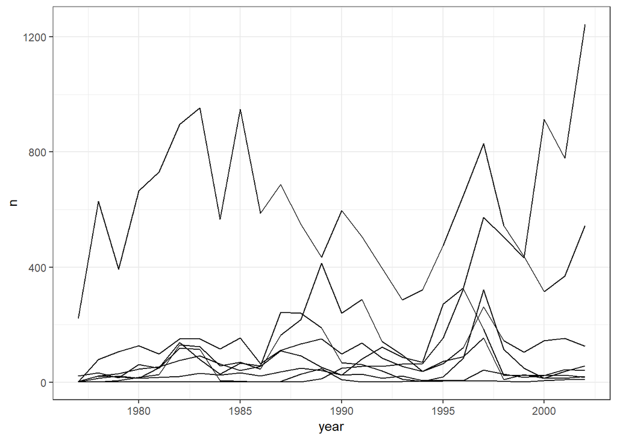

```r
ggplot(data = yearly_counts, aes(x = year, y = n, group=genus)) +
     geom_line()+
     theme_bw()
```

Same timelapse data visualization distinguishing by each genus in plot using varying colors:

```r
ggplot(data = yearly_counts, aes(x = year, y = n, color=genus)) +
  geom_line()+
  theme_bw()
```

## Integrating Pipe Operator with ggplot2

Using the pipe operator to pass data arugment to ggplot2:

```r
yearly_counts %>%
  ggplot(aes(x = year,  y= n, color = genus))+
  geom_line()+
  theme_bw()
```

Linking data manipulation with consequent data visualization using pipes:

```r
yearly_counts_graph <- surveys_complete %>%
    count(year, genus) %>%
    ggplot(mapping = aes(x = year, y = n, color = genus)) +
    geom_line() +
    theme_bw()

yearly_counts_graph
```

## Faceting

To create a time series plot for each genus, faceting is used to split one plot into multiple plots based on a factor in the dataset.

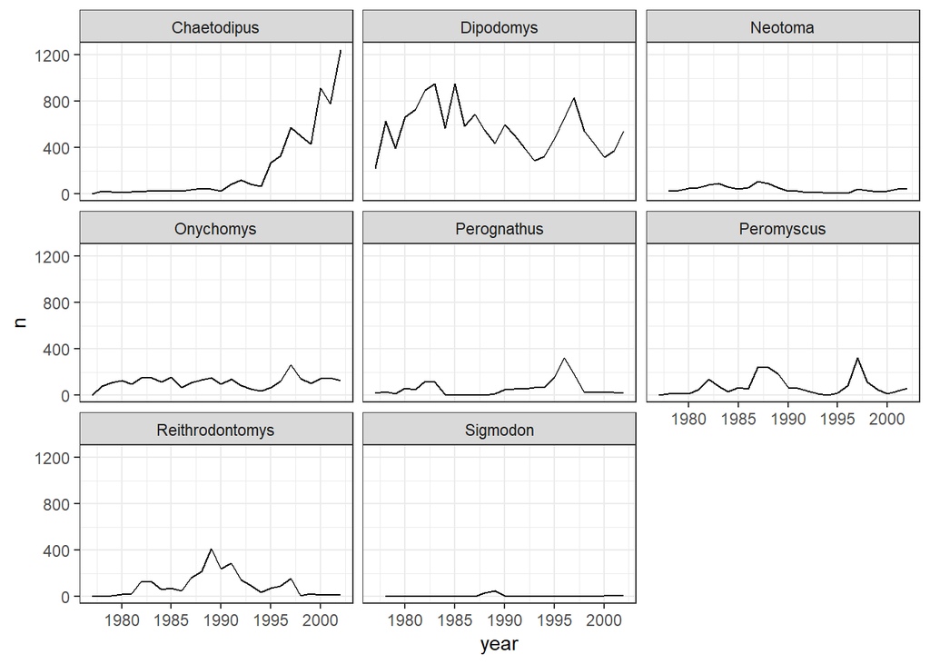

```r
ggplot(data = yearly_counts, aes(x = year, y = n))+
  geom_line()+
  facet_wrap(facets = vars(genus))+
  theme_bw()
```

To split the line in each plot by the sex of each individual, the following steps are performed. Firstly, the data frame is grouped by sex in addition to year and genus.

```r
yearly_sex_counts <- surveys_complete %>%
                     count(year, genus, sex)

yearly_sex_counts
```

```
## # A tibble: 372 x 4
##     year genus           sex       n
##    <dbl> <chr>           <chr> <int>
##  1  1977 Chaetodipus     F         3
##  2  1977 Dipodomys       F       103
##  3  1977 Dipodomys       M       119
##  4  1977 Onychomys       F         1
##  5  1977 Perognathus     F        14
##  6  1977 Perognathus     M         8
##  7  1977 Peromyscus      M         2
##  8  1977 Reithrodontomys F         1
##  9  1977 Reithrodontomys M         1
## 10  1978 Chaetodipus     F        10
## # ... with 362 more rows
```

Secondly, the faceted plot is created by passing this additional variable into the color argument.

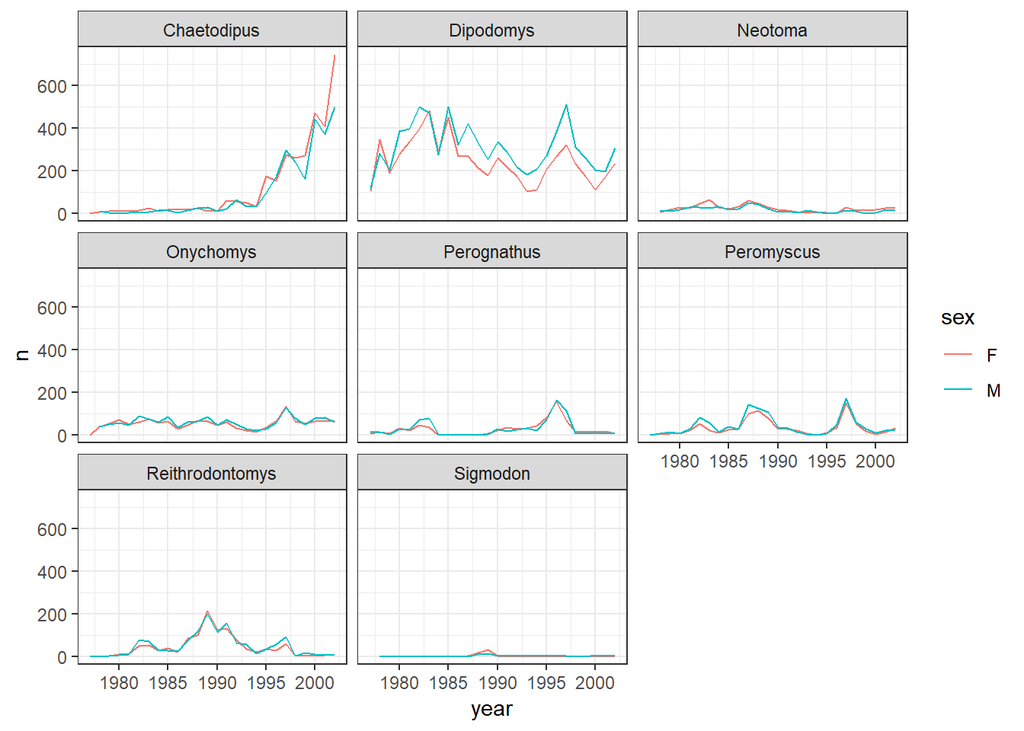

```r
ggplot(data = yearly_sex_counts, mapping = aes(x = year, y = n, color = sex)) +
  geom_line() +
  facet_wrap(facets = vars(genus)) +
  theme_bw()
```

Facet by both sex and genus in one plot:

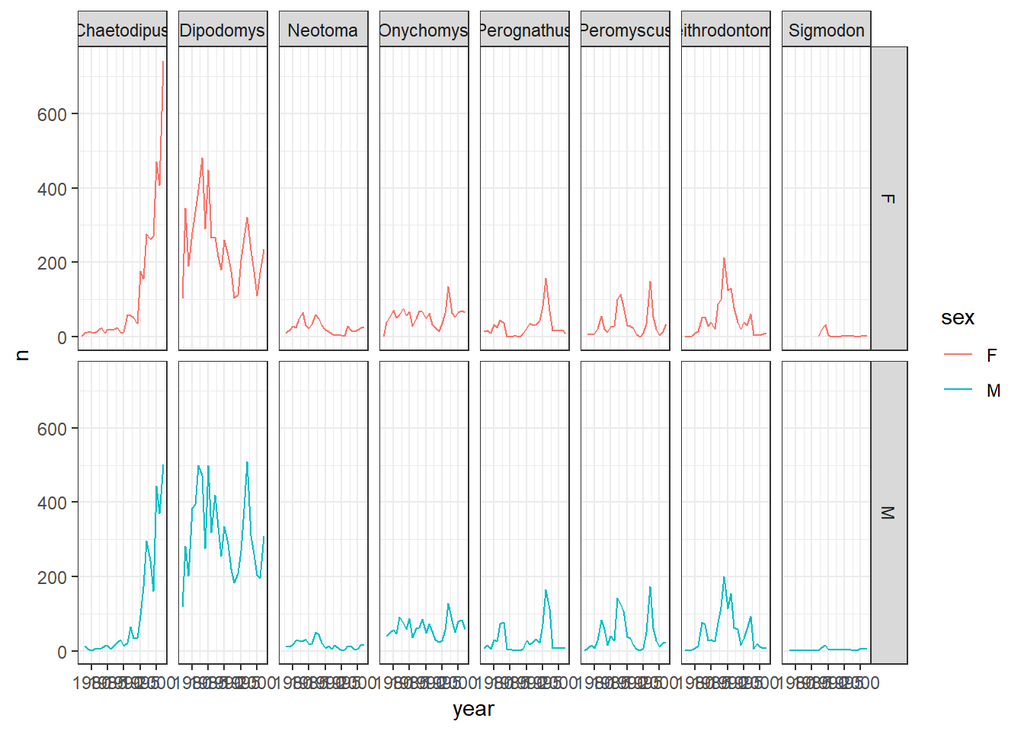

```r
ggplot(data = yearly_sex_counts,
       mapping = aes(x = year, y = n, color = sex)) +
  geom_line() +
  facet_grid(rows = vars(sex), cols = vars(genus)) +
  theme_bw()
```

Organizing the panels only by rows or columns:

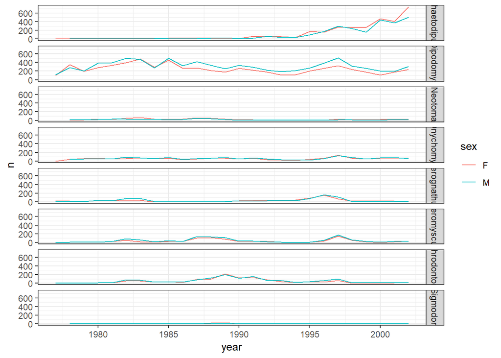

```r
#One column, facet by rows
ggplot(data = yearly_sex_counts,
       mapping = aes(x = year, y = n, color = sex)) +
  geom_line() +
  facet_grid(rows = vars(genus)) +
  theme_bw()
```

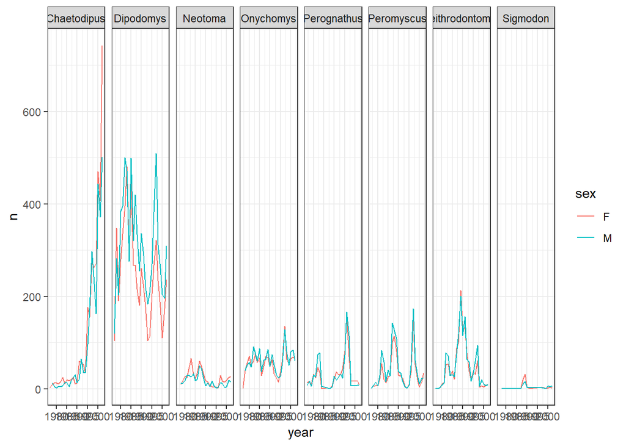

```r
#One row, facet by columns
ggplot(data = yearly_sex_counts,
       mapping = aes(x = year, y = n, color = sex)) +
  geom_line() +
  facet_grid(cols = vars(genus)) +
  theme_bw()
```

## ggplot2 Themes

An example of a plot with white background:

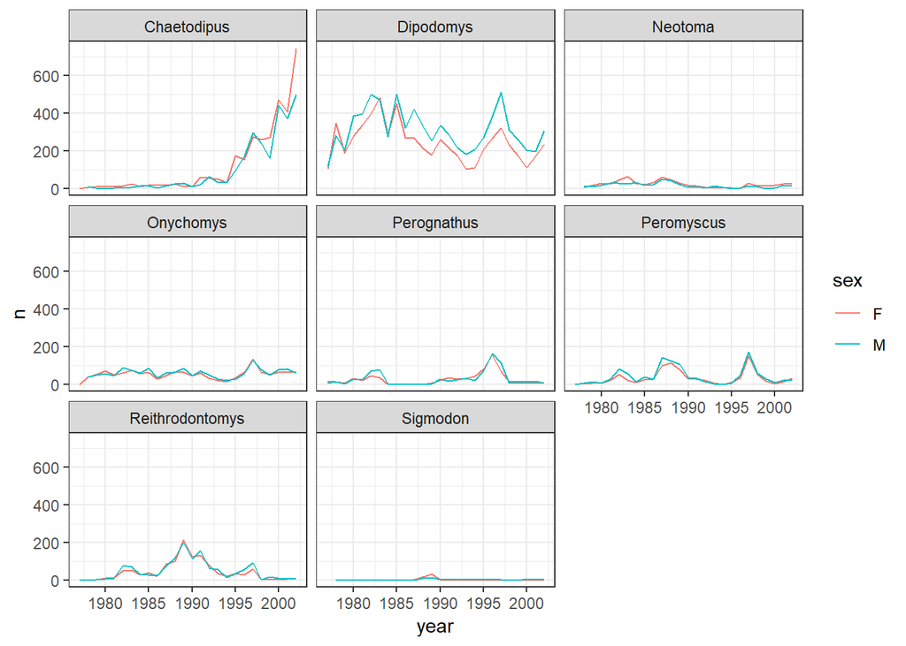

```r
ggplot(data = yearly_sex_counts,
        mapping = aes(x = year, y = n, color = sex)) +
     geom_line() +
     facet_wrap(vars(genus)) +
     theme_bw()
```

## Challenge 3

A plot that depicts how the average weight of each species changes through the years:

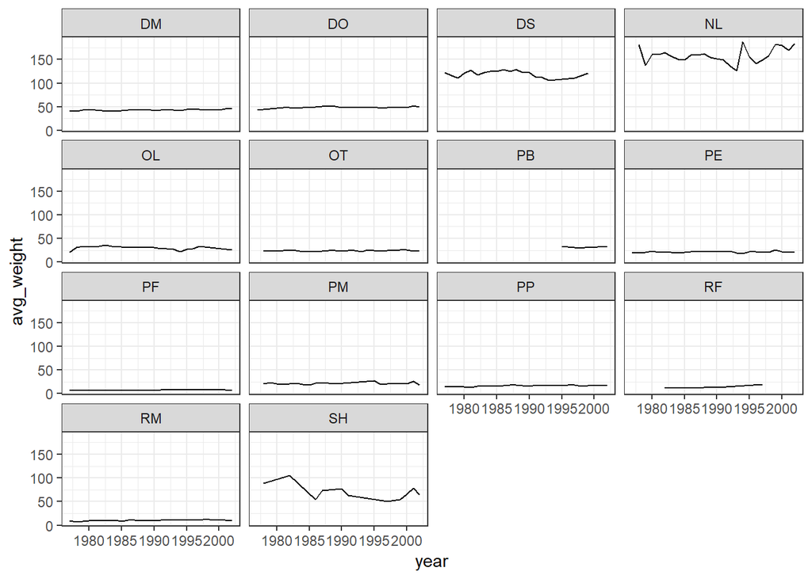

```r
surveys_complete %>%
  group_by(year, species_id) %>%
  summarise(avg_weight = mean(weight)) %>%
  ggplot(aes(x = year, y = avg_weight))+
  geom_line()+
  facet_wrap(vars(species_id))+
  theme_bw()
```

## Customization

Improving the plots by adding informative axes labels and titles as well as adjusting font sizes, orientation and positioning of text.

Adding axes labels and plot title:

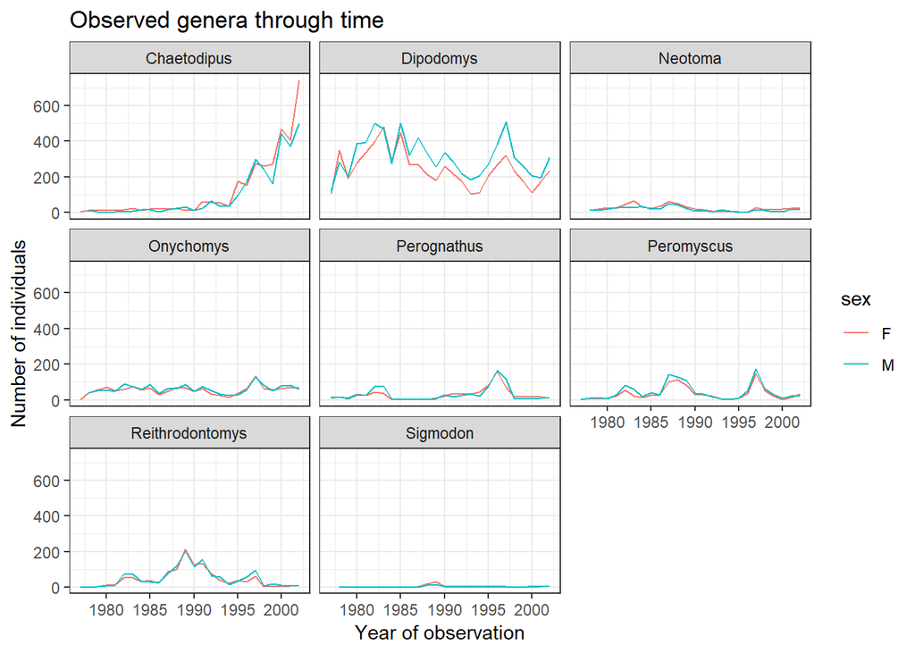

```r
customize_plot <- ggplot(data = yearly_sex_counts, aes(x = year, y = n, color = sex)) +
    geom_line() +
    facet_wrap(vars(genus)) +
    labs(title = "Observed genera through time",
         x = "Year of observation",
         y = "Number of individuals") +
    theme_bw()
customize_plot
```

Changing font size:

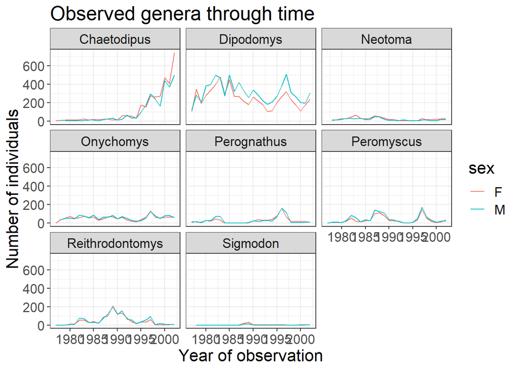

```r
customize_plot +
    theme(text=element_text(size = 16))
```

Changing orientation of labels and adjusting them vertically and horizontally to avoid overlap as well as modification of text to italicize genus:

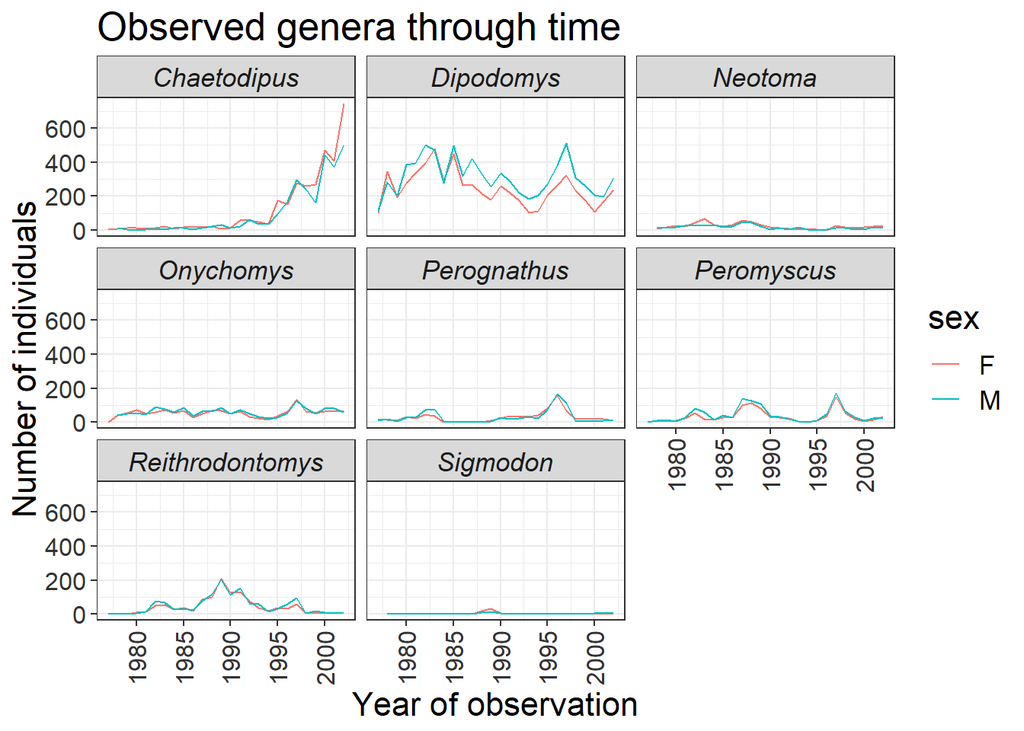

```r
customize_plot +
  theme(axis.text.x = element_text(colour = "grey20", size = 12, angle = 90, hjust =                                      0.5, vjust = 0.5),
        axis.text.y = element_text(colour = "grey20", size = 12),
        strip.text = element_text(face = "italic"),
        text = element_text(size = 16))
```

If customization better than default theme, save it as an object to apply to other plots:

```r
#theme object
grey_theme <- theme(axis.text.x = element_text(colour="grey20", size = 12,
                                               angle = 90, hjust = 0.5,
                                               vjust = 0.5),
                    axis.text.y = element_text(colour = "grey20", size = 12),
                    text=element_text(size = 16))
```

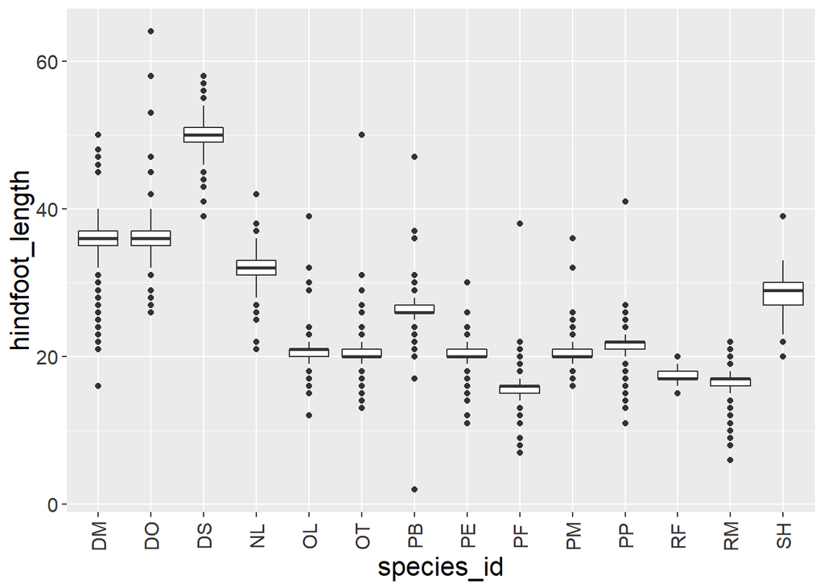

```r
#applying theme object to a barplot
ggplot(surveys_complete, aes(x = species_id, y = hindfoot_length)) +
    geom_boxplot() +
    grey_theme
```

## Challenge 4

The goal is to improve the following plot to make it more readable:

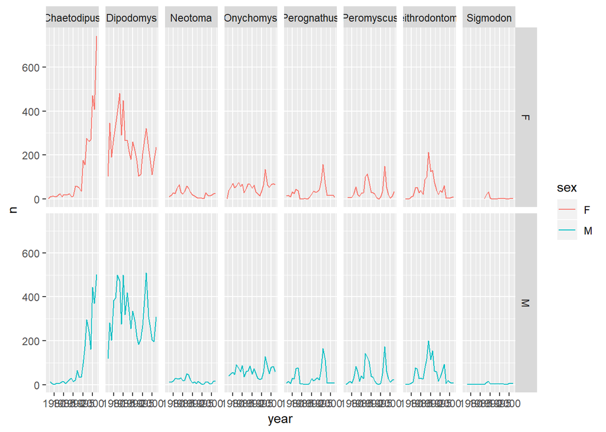

```r
ggplot(data = yearly_sex_counts,
       mapping = aes(x = year, y = n, color = sex)) +
  geom_line() +
  facet_grid(rows = vars(sex), cols =  vars(genus))
```

Plot theme object to apply to improved plot:

```r
plot_theme <- theme(axis.text.x = element_text(colour="grey10", size = 10,
                                               angle = 45, hjust = 0.5,
                                               vjust = 0.5),
                    axis.text.y = element_text(colour = "grey10", size = 10),
                    text=element_text(size = 12))
```

An improved and more readable plot with axes labeling and adjusting orientation to avoid overlaps:

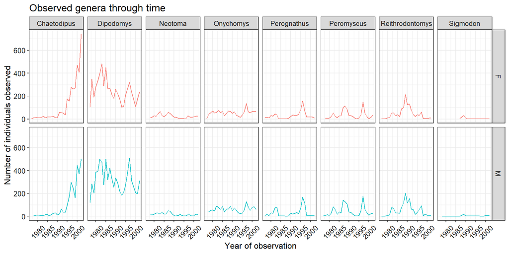

```r
ggplot(data = yearly_sex_counts,
       mapping = aes(x = year, y = n, color = sex)) +
  geom_line() +
  facet_grid(rows = vars(sex), cols =  vars(genus)) +
  labs(title = 'Observed genera through time',
       x = 'Year of observation',
       y = 'Number of individuals observed')+
  theme_bw()+
  theme(legend.position = "none")+
  plot_theme
```

## Arranging and Exporting Plots

Combining separate ggplots into a single figure using grid.arrange():

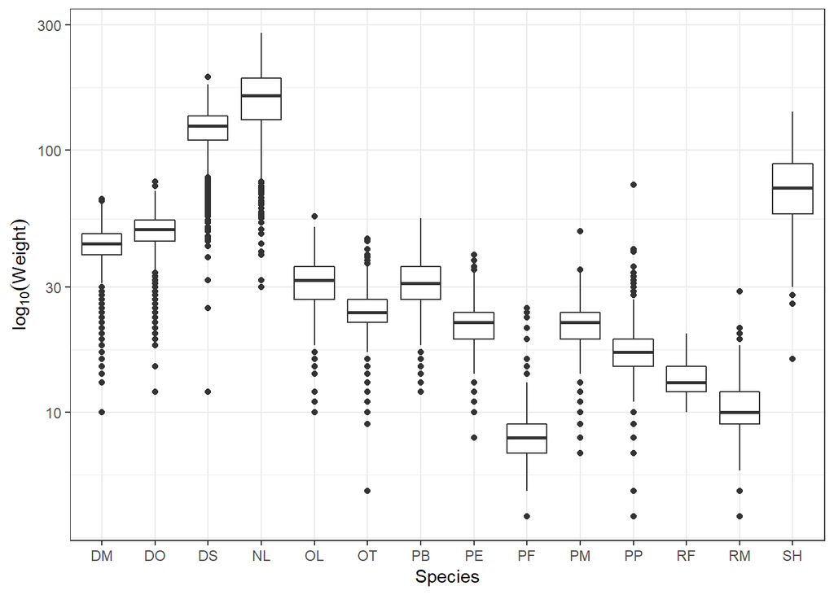

```r
spp_weight_boxplot <- ggplot(data = surveys_complete,
                             aes(x = species_id, y = weight)) +
  geom_boxplot() +
  labs(x = "Species",
       y = expression(log[10](Weight))) +
  scale_y_log10() +
  labs()+
  theme_bw()

spp_weight_boxplot
```

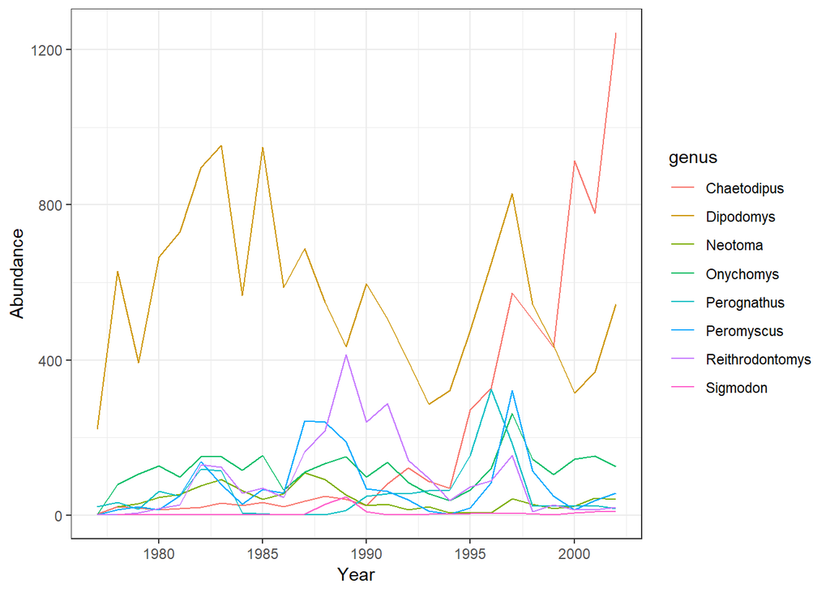

```r
spp_count_plot <- ggplot(data = yearly_counts,
                         aes(x = year, y = n, color = genus)) +
  geom_line() +
  labs(x = "Year", y = "Abundance")+
  theme_bw()

spp_count_plot
```

Combining the previous 2 plots into a single side-by-side plot:

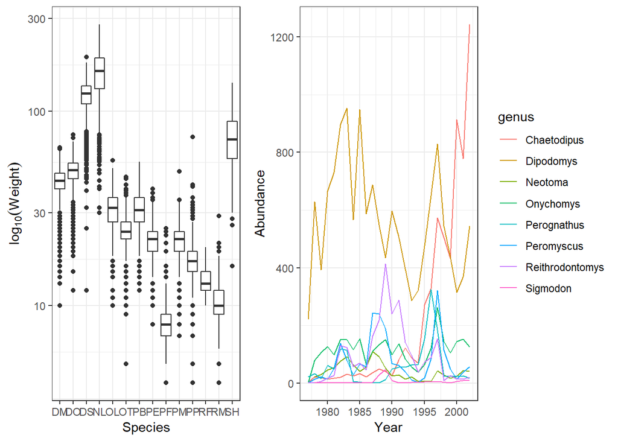

```r
grid.arrange(spp_weight_boxplot, spp_count_plot, ncol = 2, widths = c(4, 6))
```

Saving plots using ggsave:

```r
my_plot <- ggplot(data = yearly_sex_counts,
                  aes(x = year, y = n, color = sex)) +
    geom_line() +
    facet_wrap(vars(genus)) +
    labs(title = "Observed genera through time",
        x = "Year of observation",
        y = "Number of individuals") +
    theme_bw() +
    theme(axis.text.x = element_text(colour = "grey20", size = 12, angle = 90,
                                     hjust = 0.5, vjust = 0.5),
          axis.text.y = element_text(colour = "grey20", size = 12),
          text = element_text(size = 16))

ggsave("name_of_file.png", my_plot, width = 15, height = 10)

## This also works for grid.arrange() plots
combo_plot <- grid.arrange(spp_weight_boxplot, spp_count_plot, ncol = 2,
                           widths = c(4, 6))
ggsave("combo_plot_abun_weight.png", combo_plot, width = 10, dpi = 300)
```